# Reproducible research project 1 rework

Praveen Arora

16/11/2020

## Assignment Instructions

1.Code for reading in the dataset and/or processing the data 2.Histogram of the total number of steps taken each day 3.Mean and median number of steps taken each day 4.Time series plot of the average number of steps taken 5.The 5-minute interval that, on average, contains the maximum number of steps 6.Code to describe and show a strategy for imputing missing data 7.Histogram of the total number of steps taken each day after missing values are imputed 8.Panel plot comparing the average number of steps taken per 5-minute interval across weekdays and weekends

## Step 1 reading the file and formatting the date and loading the libraries needed

```r
setwd("c:/users/Praveen/Desktop/Coursera/Data")
activity <- read.csv("activity.csv")
library(data.table)
library(lubridate)
library(lattice)
```

##displaying the loaded data

```r
dim(activity)
```

```
## [1] 17568     3
```

```r
head(activity)
```

```
##   steps       date interval
## 1    NA 2012-10-01        0
## 2    NA 2012-10-01        5
## 3    NA 2012-10-01       10
## 4    NA 2012-10-01       15
## 5    NA 2012-10-01       20
## 6    NA 2012-10-01       25
```

```r
names(activity)
```

```
## [1] "steps"    "date"     "interval"
```

```r
summary(activity)
```

```
##      steps            date              interval
##  Min.   :  0.00   Length:17568       Min.   :   0.0
##  1st Qu.:  0.00   Class :character   1st Qu.: 588.8
##  Median :  0.00   Mode  :character   Median :1177.5
##  Mean   : 37.38                      Mean   :1177.5
##  3rd Qu.: 12.00                      3rd Qu.:1766.2
##  Max.   :806.00                      Max.   :2355.0
##  NA's   :2304
```

```r
#changing to date format

activity$date<- ymd(activity$date)

#total number of missing data
sum(is.na(activity$steps))
```

```
## [1] 2304
```

## Step 2 plotting the histogram of number of steps in a day and seeing if it comes in .MD file

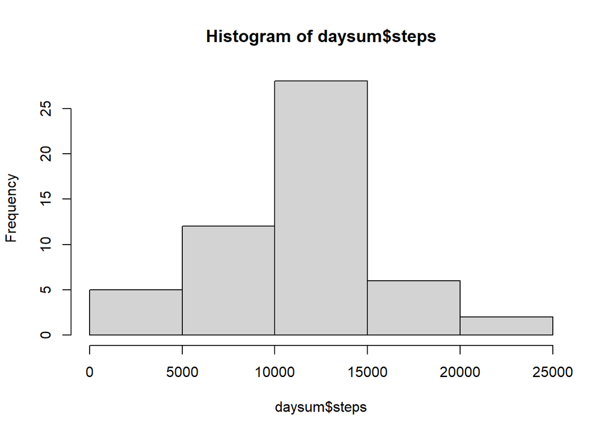

```r
daysum <- aggregate(steps ~ date, activity, sum, na.rm=TRUE)
hist(daysum$steps)
```

## Step3 calculating mean, median, sum by date and by interval and plotting histogram of daysteps

```r
meanstepsinaday <- mean(daysum$steps)
meanstepsinaday
```

```
## [1] 10766.19
```

```r
medianstepsinaday <- median(daysum$steps)
medianstepsinaday
```

```
## [1] 10765
```

##creating variables to cover number of steps within interval, additional variable created for testing functionality later

```r
intervalsum <- aggregate(steps ~ interval, activity, sum, na.rm=TRUE)
intervalmean <- aggregate(steps ~ interval, activity, mean, na.rm=TRUE)
intervalmedian <- aggregate(steps ~ interval, activity, median, na.rm=TRUE)
```